# Lab6_anova

2023-01-31

```r
library(tidyverse)
#install.packages("rstatix")
library(rstatix) # for ANOVA
library(ggpubr) # for boxplots with p-values
library(car) # for Levene test
library(ez) # for ezANOVA
```

## Разминка

### Плохие практики в дизайне научного исследования

http://statcheck.io

- Формулировка гипотезы ad-hoc
- Выбор зависимых переменных пост-фактум
- Обсуждение неожиданных результатов как ожидаемых, если результаты оказываются статистически значимыми, но направлены в другую сторону, чем предполагалось в гипотезе
- Остановка набора испытуемых/объема корпусного датасета при достижении уровня значимости (Optional stopping) рано или поздно Вы получите статистически значимые результаты. В любом случае, даже если эффекта нет
- Неправильное округление до .05. Всякий раз, когда видите p = .05, будьте внимательны
- Использование односторонних тестов для сравнения средних. Не используйте правосторонний t-test !

### Вспоминаем:

- Тестирование нулевой гипотезы и p-value
- t-test для средних значений в двух группах (непрерывная переменная)
- это о различиях между выборками

### Нельзя много раз проводить t-test

mean(A) ~ mean(B)  
mean(A) ~ mean(C)  
mean(B) ~ mean(C)

## Дисперсионный анализ (ANOVA)

В R функции: * `aov()` – базовый R (пакет stats), обертка над `lm()` для вывода данных в формате дисперсионного анализа  
* `anova_test()` – пакет `rstatix`  
* `ezANOVA()` – пакет `ez` (easy)  
и др.

### Межгрупповой анализ (One-way ANOVA)

```r
diet <- read_csv("https://raw.githubusercontent.com/Pozdniakov/tidy_stats/master/data/stcp-Rdataset-Diet.csv")
head(diet$Diet)
```

```
## [1] 2 2 1 1 1 1
```

```r
diet <- diet %>%
  mutate(weight.loss = weight6weeks - pre.weight,
         Dietf = factor(Diet, labels = LETTERS[1:3]),
         Person = factor(Person)) %>%
  drop_na()
diet %>%
  select(Dietf) %>%
  distinct()
```

```
## # A tibble: 3 × 1
##   Dietf
##   <fct>
## 1 A
## 2 B
## 3 C
```

```r
# one-way anova
aov_model <- aov(weight.loss ~ Dietf, diet)
aov_model
```

```
## Call:
##    aov(formula = weight.loss ~ Dietf, data = diet)
##
## Terms:
##                    Dietf Residuals
## Sum of Squares   60.5270  410.4018
## Deg. of Freedom        2        73
##
## Residual standard error: 2.371064
## Estimated effects may be unbalanced
```

```r
summary(aov_model)
```

```
##             Df Sum Sq Mean Sq F value Pr(>F)
## Dietf        2   60.5  30.264   5.383 0.0066 **
## Residuals   73  410.4   5.622
## ---
## Signif. codes:  0 '***' 0.001 '**' 0.01 '*' 0.05 '.' 0.1 ' ' 1
```

```r
# post-hoc
TukeyHSD(aov_model)
```

```
##   Tukey multiple comparisons of means
##     95% family-wise confidence level
##
## Fit: aov(formula = weight.loss ~ Dietf, data = diet)
##
## $Dietf
##          diff       lwr        upr     p adj
## B-A  0.032000 -1.589085  1.6530850 0.9987711
## C-A -1.848148 -3.439554 -0.2567422 0.0188047
## C-B -1.880148 -3.454614 -0.3056826 0.0152020
```

Post-hoc тест Тьюки показал, что есть статистически значимая разница между средними выборок B и С, A и C.

### Дисперсионный анализ с повторными измерениями (Repeated-measures ANOVA)

```r
dietlong <- diet %>%
  pivot_longer(cols = c(pre.weight, weight6weeks),
               names_to = "time",
               values_to = "weight")

dietlong <- diet %>%
  pivot_longer(cols = c(pre.weight, weight6weeks),
               names_to = "time",
               values_to = "weight")

res.aov <- anova_test(data = dietlong, dv = weight, wid = Person, within = time)
get_anova_table(res.aov)
```

```
## ANOVA Table (type III tests)
##
##   Effect DFn DFd       F        p p<.05   ges
## 1   time   1  75 188.471 3.72e-22     * 0.058
```

Пример использования функции ezANOVA:

```r
dietlongC <- dietlong %>%
          filter(Dietf == "C") %>%
          droplevels()

ezANOVA(data = dietlongC,
        dv = weight,
        wid = Person,
        within = time)
```

```
## $ANOVA
##   Effect DFn DFd        F            p p<.05       ges
## 2   time   1  26 124.6949 2.030459e-11     * 0.0986036
```

```r
ezANOVA(dietlongC, dv=weight, wid=Person, within=time, detailed = TRUE, type =
3)
```

```
## $ANOVA
##        Effect DFn DFd         SSn       SSd         F            p p<.05
## 1 (Intercept)   1  26 272640.1667 3196.2333 2217.8119 1.057931e-26     *
## 2        time   1  26    357.7963   74.6037  124.6949 2.030459e-11     *
##         ges
## 1 0.9881453
## 2 0.0986036
```

Детальная таблица выдает степени свободы для числителя (DFn(umerator)) и знаменателя (DFd(enominator)), то есть DFeffect и DFerror, соответствующие суммы квадратов (SSeffect и SSerror), F-статистику, p-value и величину эффекта (generalized eta-squared).

Напишите ваши выводы по результатам дисперсионного анализа с повторными измерениями по данным dietlongC:

Примечание. Функция `ezANOVA()` полезна тем, что может выдавать Mauchly’s Test for Sphericity (для within-subjects факторов с более чем двумя уровнями), поправку на сферичность (Greenhouse-Geisser и Huynh-Feldt epsilon и adjusted p-values), Levene’s Test for Homogeneity (для дизайна без повторных измерений).

### Упражнение 1

Датасет `bilingual` представляет псевдоисследование усвоения языка билингвами, которые используют один язык только дома, а другой - в школе.  
* subj – ID участника  
* language – сфера использования языка (`school`/`home.only`)  
* age – возраст участника  
* gender – пол участника  
* mlu – средняя длина высказывания (mean length of utterance)

Возьмите часть данных, описывающих использование домашнего языка (`home.only`). Примените однофакторный дисперсионный анализ с повторными измерениями, чтобы изучить эффект возраста на среднюю длину высказывания. Перед этим приведите описательные статистики и графики.

```r
bilingual <- read_tsv("http://coltekin.net/cagri/R/data/bilingual.txt") %>%
  mutate_if(is.character, factor) %>%
  mutate(age = factor(age, levels = c("preschool","firstgrade","secondgrade")),
         subj = factor(subj)) %>%
  filter(language == "home.only") %>%
  droplevels()
str(bilingual)
```

```
## tibble [60 × 5] (S3: tbl_df/tbl/data.frame)
##  $ subj    : Factor w/ 20 levels "1","2","3","4",..: 1 1 1 2 2 2 3 3 3 4 ...
##  $ language: Factor w/ 1 level "home.only": 1 1 1 1 1 1 1 1 1 1 ...
##  $ age     : Factor w/ 3 levels "preschool","firstgrade",..: 1 2 3 1 2 3 1 2 3 1 ...
##  $ gender  : Factor w/ 2 levels "F","M": 1 1 1 1 1 1 1 1 1 1 ...
##  $ mlu     : num [1:60] 3.71 4.7 4.31 3.08 4.33 ...
```

```r
skimr::skim(bilingual)
```

Data summary

| Name | bilingual |
| --- | --- |
| Number of rows | 60 |
| Number of columns | 5 |
| _______________________ |  |
| Column type frequency: |  |
| factor | 4 |
| numeric | 1 |
| ________________________ |  |
| Group variables | None |

**Variable type: factor**

| skim_variable | n_missing | complete_rate | ordered | n_unique | top_counts |
| --- | --- | --- | --- | --- | --- |
| subj | 0 | 1 | FALSE | 20 | 1: 3, 2: 3, 3: 3, 4: 3 |
| language | 0 | 1 | FALSE | 1 | hom: 60 |
| age | 0 | 1 | FALSE | 3 | pre: 20, fir: 20, sec: 20 |
| gender | 0 | 1 | FALSE | 2 | F: 30, M: 30 |

**Variable type: numeric**

| skim_variable | n_missing | complete_rate | mean | sd | p0 | p25 | p50 | p75 | p100 | hist |
| --- | --- | --- | --- | --- | --- | --- | --- | --- | --- | --- |
| mlu | 0 | 1 | 4.31 | 1.3 | 1.51 | 3.47 | 4.27 | 5.44 | 7.18 | ▂▇▆▃▃ |

```r
bilingual %>%
  group_by(age) %>%
  rstatix::get_summary_stats(mlu, type = "mean_sd")
```

```
## # A tibble: 3 × 5
##   age         variable     n  mean    sd
##   <fct>       <fct>    <dbl> <dbl> <dbl>
## 1 preschool   mlu         20  3.89  1.22
## 2 firstgrade  mlu         20  4.25  1.12
## 3 secondgrade mlu         20  4.80  1.44
```

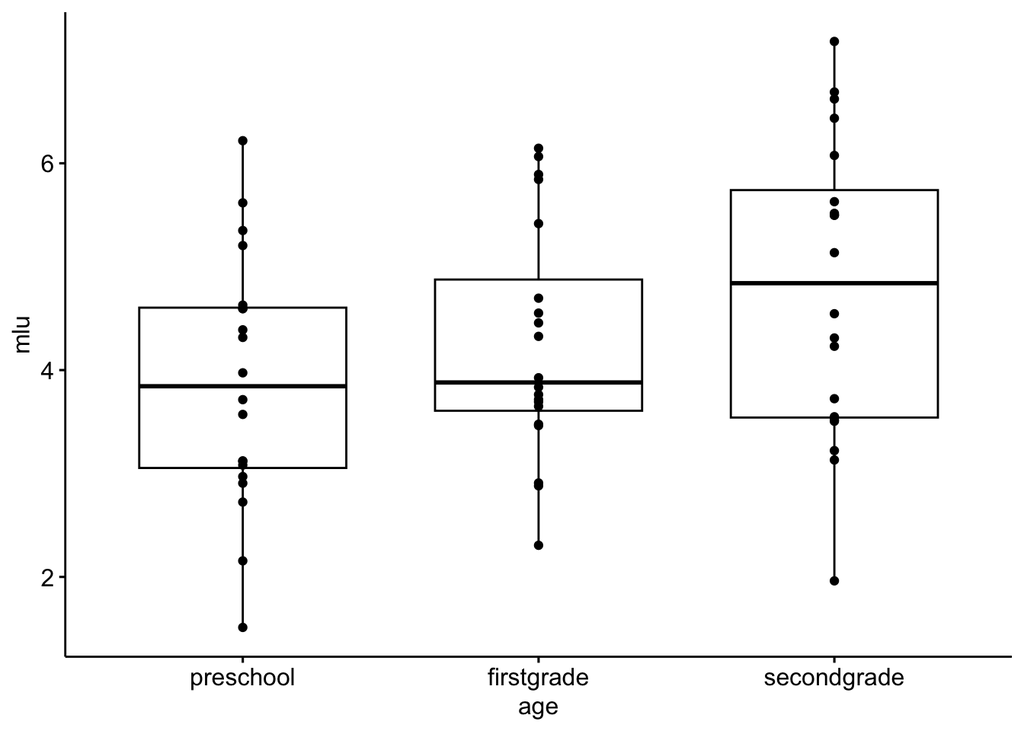

```r
ggpubr::ggboxplot(bilingual, x = "age", y = "mlu", add = "point")
```

```r
bilingual %>%
  group_by(age) %>%
  rstatix::identify_outliers(mlu)
```

```
## [1] age        subj       language   gender     mlu        is.outlier is.extreme
## <0 rows> (or 0-length row.names)
```

```r
# normality test
bilingual %>%
  group_by(age) %>%
  shapiro_test(mlu)
```

```
## # A tibble: 3 × 4
##   age         variable statistic     p
##   <fct>       <chr>        <dbl> <dbl>
## 1 preschool   mlu          0.982 0.960
## 2 firstgrade  mlu          0.935 0.189
## 3 secondgrade mlu          0.961 0.570
```

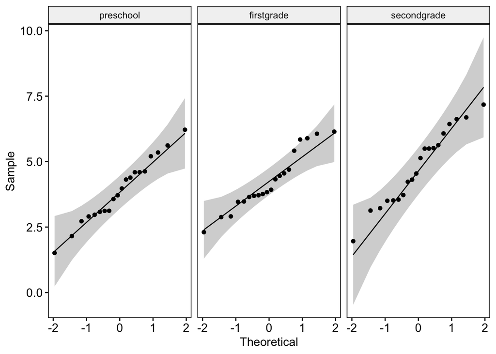

```r
ggpubr::ggqqplot(bilingual, "mlu", facet.by = "age")
```

```r
res.aov <- anova_test(data = bilingual, dv = mlu, wid = subj, within = age)
get_anova_table(res.aov)
```

```
## ANOVA Table (type III tests)
##
##   Effect DFn DFd     F     p p<.05   ges
## 1    age   2  38 5.682 0.007     * 0.084
```

```r
# p-value < 0.5, so there is a significant difference found across age

# the same with aov()
#summary(aov(mlu ~ age + Error(subj/age), data=bilingual))
```

```r
# post-hoc
pwc <- bilingual %>%
  pairwise_t_test(
    mlu ~ age, paired = TRUE,
    p.adjust.method = "bonferroni"
    )
pwc
```

```
## # A tibble: 3 × 10
##   .y.   group1     group2         n1    n2 statistic    df       p p.adj p.adj…¹
## * <chr> <chr>      <chr>       <int> <int>     <dbl> <dbl>   <dbl> <dbl> <chr>
## 1 mlu   preschool  firstgrade     20    20     -1.35    19 1.93e-1 0.579 ns
## 2 mlu   preschool  secondgrade    20    20     -4.10    19 6.12e-4 0.002 **
## 3 mlu   firstgrade secondgrade    20    20     -1.73    19 1   e-1 0.3   ns
## # … with abbreviated variable name ¹p.adj.signif
```

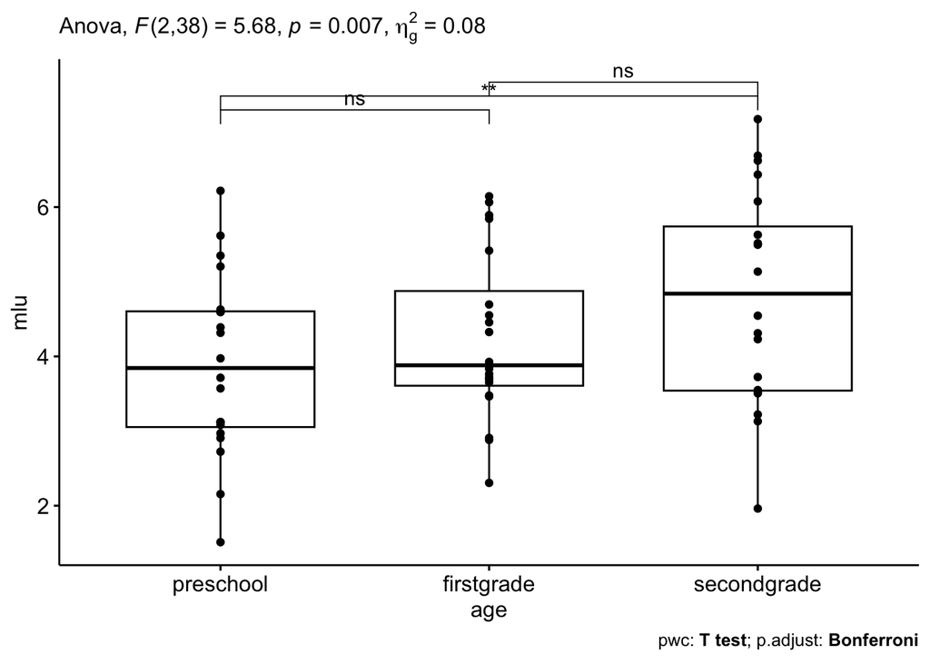

```r
# boxplots with p-values
pwc <- pwc %>% add_xy_position(x = "age")
ggboxplot(bilingual, x = "age", y = "mlu", add = "point") +
  stat_pvalue_manual(pwc) +
  labs(
    subtitle = get_test_label(res.aov, detailed = TRUE),
    caption = get_pwc_label(pwc)
  )
```

Был проведен дисперсионный анализ с повторными измерениями по переменной age, который показал (F(2,38)=5,682, p-value=0.007), что есть значимое различие в среднем показателе mlu при повторных измерениях в разных возрастах. Величина эффекта / Доля объясненной дисперсии 8,4%. Попарные post-hoc сравнения показали, что есть значимое различие между группами preschool и secondgrade (adjusted p-value=0.002).

### Непараметрический тест Фридмана

для повторных измерений, аналог one-way RM-ANOVA. Формула имеет вид `a ~ b | c`, где a (numeric) – зависимая переменная;  
b (factor) – повторное измерение/условие (within-subjects variable);  
c (factor) – участник или стимул (individuals/subjects identifier). Должен быть уникальным для каждого измеряемого.

```r
res.fried <- bilingual %>% friedman_test(mlu ~ age|subj)
res.fried
```

```
## # A tibble: 1 × 6
##   .y.       n statistic    df      p method
## * <chr> <int>     <dbl> <dbl>  <dbl> <chr>
## 1 mlu      20       9.1     2 0.0106 Friedman test
```

```r
# Effect size of the Friedman test
# The Kendall’s W = Friedman_stats/N(k-1)
bilingual %>% friedman_effsize(mlu ~ age |subj)
```

```
## # A tibble: 1 × 5
##   .y.       n effsize method    magnitude
## * <chr> <int>   <dbl> <chr>     <ord>
## 1 mlu      20   0.227 Kendall W small
```

```r
# Pairwise comparisons using paired Wilcoxon signed-rank test
pwc <- bilingual %>%
  wilcox_test(mlu ~ age, paired = TRUE, p.adjust.method = "bonferroni")
pwc
```

```
## # A tibble: 3 × 9
##   .y.   group1     group2         n1    n2 statistic        p p.adj p.adj.signif
## * <chr> <chr>      <chr>       <int> <int>     <dbl>    <dbl> <dbl> <chr>
## 1 mlu   preschool  firstgrade     20    20        73 0.245    0.735 ns
## 2 mlu   preschool  secondgrade    20    20        19 0.000586 0.002 **
## 3 mlu   firstgrade secondgrade    20    20        60 0.097    0.292 ns
```

```r
# Pairwise comparisons using sign test:
pwc2 <- bilingual %>%
  sign_test(mlu ~ age, p.adjust.method = "bonferroni")
pwc2
```

```
## # A tibble: 3 × 10
##   .y.   group1     group2         n1    n2 statistic    df     p p.adj p.adj.s…¹
## * <chr> <chr>      <chr>       <int> <int>     <dbl> <dbl> <dbl> <dbl> <chr>
## 1 mlu   preschool  firstgrade     20    20         8    20 0.503 1     ns
## 2 mlu   preschool  secondgrade    20    20         3    20 0.003 0.008 **
## 3 mlu   firstgrade secondgrade    20    20         7    20 0.263 0.789 ns
## # … with abbreviated variable name ¹p.adj.signif
```

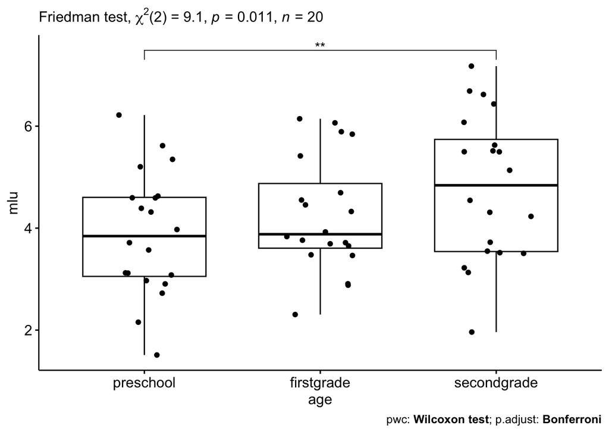

```r
# Visualization: box plots with p-values
pwc <- pwc %>% add_xy_position(x = "age")
ggboxplot(bilingual, x = "age", y = "mlu", add = "jitter") +
  stat_pvalue_manual(pwc, hide.ns = TRUE) +
  labs(
    subtitle = get_test_label(res.fried,  detailed = TRUE),
    caption = get_pwc_label(pwc)
  )
```

### Двухфакторная ANOVA с повторными измерениями

На полном датасете `bilingual`, включающем использование обоих языков (`school` и `home.only`), примените двухфакторный дисперсионный анализ с повторными измерениями, чтобы изучить эффект языка и возраста на среднюю длину высказывания. Перед этим приведите описательные статистики и графики.

```r
bilingual <- read_tsv("http://coltekin.net/cagri/R/data/bilingual.txt") %>%
  mutate_if(is.character, factor) %>%
  mutate(age = factor(age, levels = c("preschool","firstgrade","secondgrade")))
summary(bilingual)
```

```
##       subj            language           age     gender      mlu
##  Min.   : 1.00   home.only:60   preschool  :40   F:60   Min.   :1.039
##  1st Qu.: 5.75   school   :60   firstgrade :40   M:60   1st Qu.:3.548
##  Median :10.50                  secondgrade:40          Median :4.452
##  Mean   :10.50                                          Mean   :4.557
##  3rd Qu.:15.25                                          3rd Qu.:5.587
##  Max.   :20.00                                          Max.   :9.962
```

```r
# get random rows of the data by groups
bilingual %>% sample_n_by(language, age, size = 1)
```

```
## # A tibble: 6 × 5
##    subj language  age         gender   mlu
##   <dbl> <fct>     <fct>       <fct>  <dbl>
## 1     6 home.only preschool   F       5.35
## 2    13 home.only firstgrade  M       5.42
## 3     3 home.only secondgrade F       3.52
## 4    17 school    preschool   M       3.55
## 5     3 school    firstgrade  F       3.51
## 6    20 school    secondgrade M       4.20
```

```r
# descriptive statistics
bilingual %>%
  group_by(language, age) %>%
  get_summary_stats(mlu, type = "mean_sd")
```

```
## # A tibble: 6 × 6
##   language  age         variable     n  mean    sd
##   <fct>     <fct>       <fct>    <dbl> <dbl> <dbl>
## 1 home.only preschool   mlu         20  3.89  1.22
## 2 home.only firstgrade  mlu         20  4.25  1.12
## 3 home.only secondgrade mlu         20  4.80  1.44
## 4 school    preschool   mlu         20  4.02  1.30
## 5 school    firstgrade  mlu         20  4.64  1.35
## 6 school    secondgrade mlu         20  5.75  1.64
```

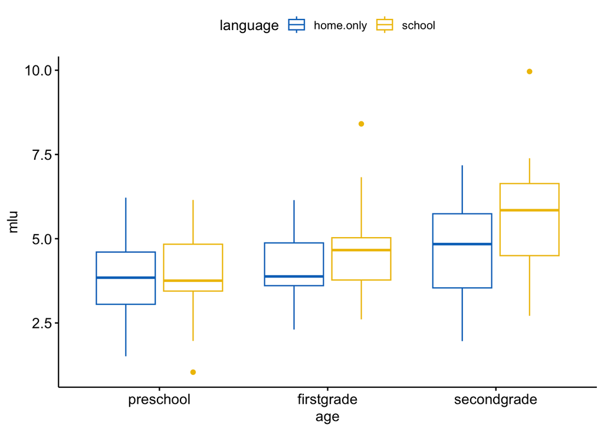

```r
# boxplots
ggboxplot(bilingual, x = "age", y = "mlu",
  color = "language", palette = "jco")
```

```r
# check extreme outliers
bilingual %>%
  group_by(language, age) %>%
  identify_outliers(mlu)
```

```
## # A tibble: 3 × 7
##   language age          subj gender   mlu is.outlier is.extreme
##   <fct>    <fct>       <dbl> <fct>  <dbl> <lgl>      <lgl>
## 1 school   preschool      15 M       1.04 TRUE       FALSE
## 2 school   firstgrade     18 M       8.41 TRUE       FALSE
## 3 school   secondgrade    18 M       9.96 TRUE       FALSE
```

```r
# check normality assumptions
bilingual %>%
  group_by(language, age) %>%
  shapiro_test(mlu)
```

```
## # A tibble: 6 × 5
##   language  age         variable statistic     p
##   <fct>     <fct>       <chr>        <dbl> <dbl>
## 1 home.only preschool   mlu          0.982 0.960
## 2 home.only firstgrade  mlu          0.935 0.189
## 3 home.only secondgrade mlu          0.961 0.570
## 4 school    preschool   mlu          0.952 0.401
## 5 school    firstgrade  mlu          0.923 0.113
## 6 school    secondgrade mlu          0.962 0.580
```

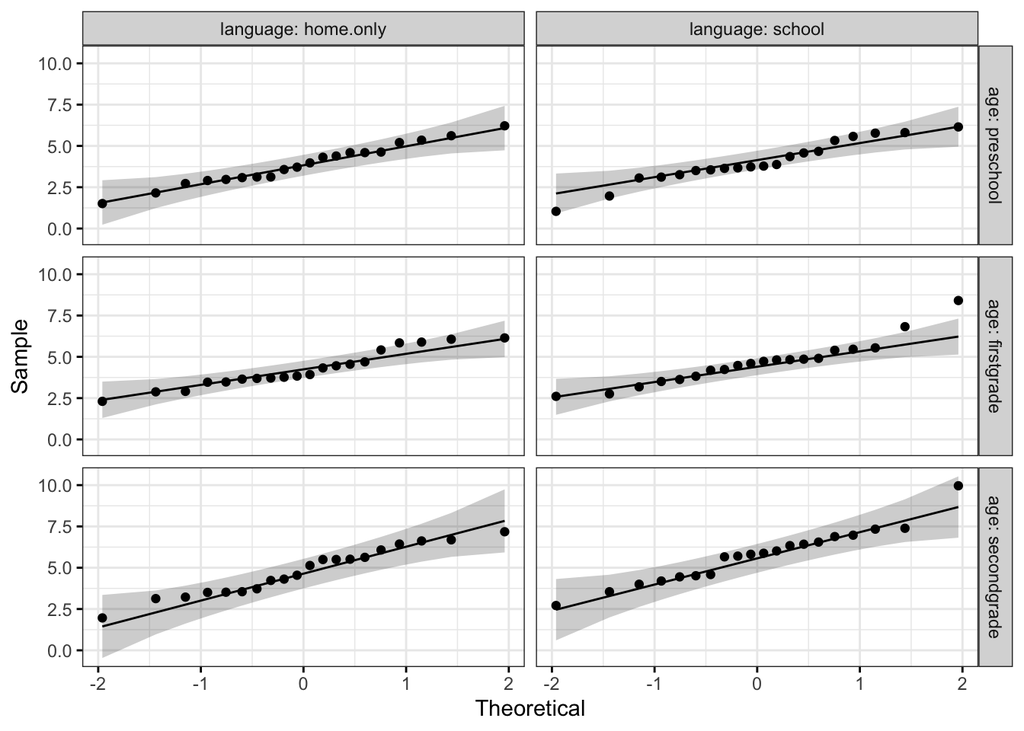

```r
ggqqplot(bilingual, "mlu", ggtheme = theme_bw()) +
  facet_grid(age ~ language, labeller = "label_both")
```

```r
# anova
res.aov <- anova_test(
  data = bilingual, dv = mlu, wid = subj,
  within = c(language, age)
  )
get_anova_table(res.aov)
```

```
## ANOVA Table (type III tests)
##
##         Effect DFn DFd      F        p p<.05   ges
## 1     language   1  19  7.076 1.50e-02     * 0.033
## 2          age   2  38 17.764 3.58e-06     * 0.145
## 3 language:age   2  38  3.003 6.20e-02       0.016
```

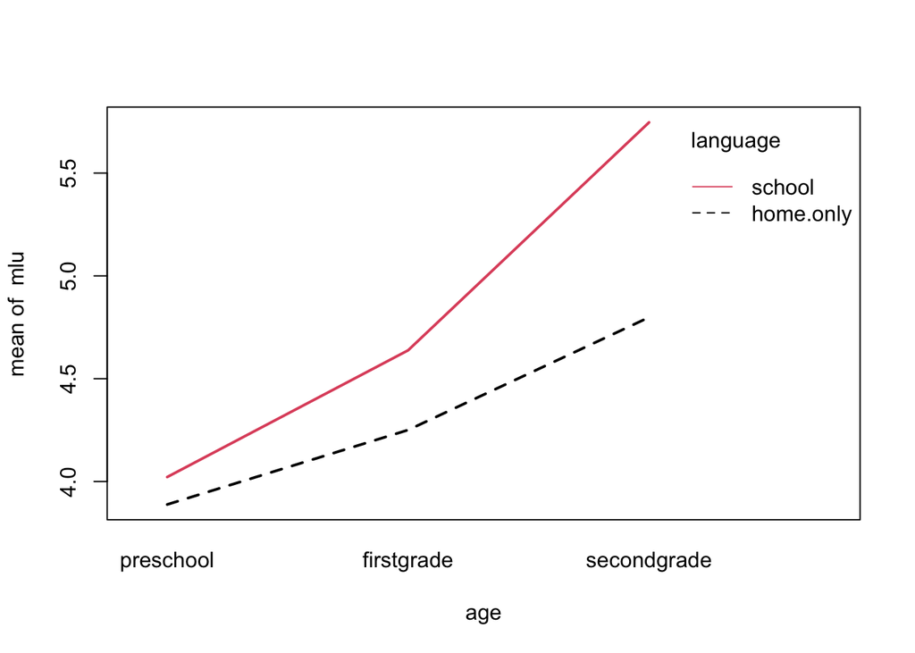

```r
# Interaction plot
with(bilingual, interaction.plot(age, language, mlu, lwd = 2, col = 1:2))
```

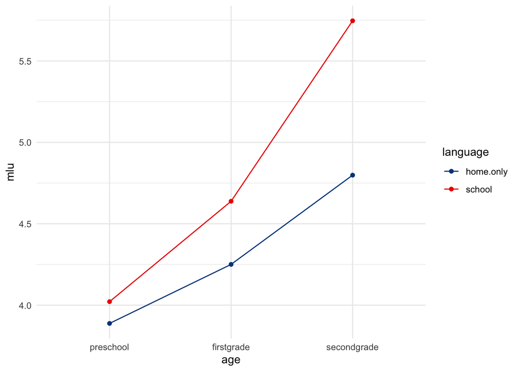

```r
# or
library(ggsci) # for scientific palettes
bilingual %>%
  ggplot() +
  aes(x = age, color = language, group = language, y = mlu) +
  stat_summary(fun = mean, geom = "point") +
  stat_summary(fun = mean, geom = "line") +
  scale_color_lancet() +
  theme_minimal()
```

```r
# or
bilingual_stat <- bilingual %>%
  group_by(language, age) %>%
  summarise(mlu_groups = mean(mlu),
            mlu_se = (sd(mlu)/sqrt(length(mlu))))
```

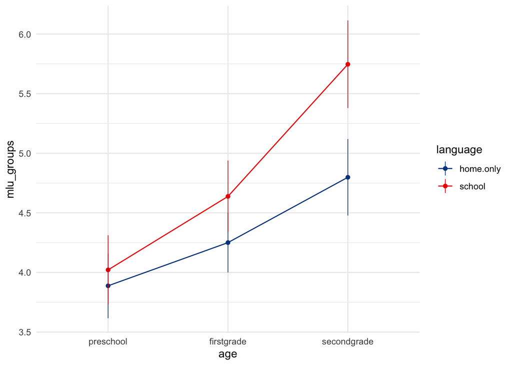

```r
bilingual_stat %>%
  ggplot() +
  aes(x = age, y = mlu_groups, color = language) +
  geom_line(aes(group = language)) +
  geom_point() +
  geom_linerange(aes(x = age, ymin = mlu_groups - mlu_se, ymax = mlu_groups + mlu_se), size = .3) +
  scale_color_lancet() +
  theme_minimal()
```

```r
# post-hoc in case of non-significant interactions
bilingual %>%
  pairwise_t_test(
    mlu ~ language, paired = TRUE,
    p.adjust.method = "bonferroni"
    )
```

```
## # A tibble: 1 × 10
##   .y.   group1    group2    n1    n2 statistic    df     p p.adj p.adj.signif
## * <chr> <chr>     <chr>  <int> <int>     <dbl> <dbl> <dbl> <dbl> <chr>
## 1 mlu   home.only school    60    60     -3.08    59 0.003 0.003 **
```

```r
bilingual %>%
  pairwise_t_test(
    mlu ~ age, paired = TRUE,
    p.adjust.method = "bonferroni"
    )
```

```
## # A tibble: 3 × 10
##   .y.   group1     group2         n1    n2 stati…¹    df       p   p.adj p.adj…²
## * <chr> <chr>      <chr>       <int> <int>   <dbl> <dbl>   <dbl>   <dbl> <chr>
## 1 mlu   preschool  firstgrade     40    40   -2.47    39 1.8 e-2 5.4 e-2 ns
## 2 mlu   preschool  secondgrade    40    40   -6.19    39 2.81e-7 8.43e-7 ****
## 3 mlu   firstgrade secondgrade    40    40   -4.29    39 1.14e-4 3.42e-4 ***
## # … with abbreviated variable names ¹statistic, ²p.adj.signif
```

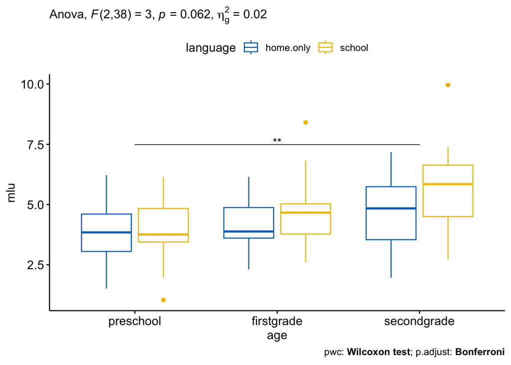

```r
# box plots with p-values
pwc <- pwc %>% add_xy_position(x = "age")
ggboxplot(bilingual, x = "age", y = "mlu",
  color = "language", palette = "jco") +
  stat_pvalue_manual(pwc, tip.length = 0, hide.ns = TRUE) +
  labs(
    subtitle = get_test_label(res.aov, detailed = TRUE),
    caption = get_pwc_label(pwc)
  )
```

Значимое взаимодействие двух факторов (language:age) означало бы, что вклад одного из факторов (например, возраста) разный в зависимости от уровня другого фактора (language). Код для post-hoc тестов при статистически значимом взаимодействии:

```r
# Effect of language on mlu in each age
one.way <- bilingual %>%
  group_by(age) %>%
  anova_test(dv = mlu, wid = subj, within = language) %>%
  get_anova_table() %>%
  adjust_pvalue(method = "bonferroni")
one.way
```

```
## # A tibble: 3 × 9
##   age         Effect     DFn   DFd     F     p `p<.05`   ges p.adj
##   <fct>       <chr>    <dbl> <dbl> <dbl> <dbl> <chr>   <dbl> <dbl>
## 1 preschool   language     1    19  0.23 0.637 ""      0.003 1
## 2 firstgrade  language     1    19  2.60 0.124 ""      0.025 0.372
## 3 secondgrade language     1    19 11.0  0.004 "*"     0.09  0.012
```

```r
# Pairwise comparisons between language groups
pwc <- bilingual %>%
  group_by(age) %>%
  pairwise_t_test(
    mlu ~ language, paired = TRUE,
    p.adjust.method = "bonferroni"
    )
pwc
```

```
## # A tibble: 3 × 11
##   age         .y.   group1  group2    n1    n2 stati…¹    df     p p.adj p.adj…²
## * <fct>       <chr> <chr>   <chr>  <int> <int>   <dbl> <dbl> <dbl> <dbl> <chr>
## 1 preschool   mlu   home.o… school    20    20  -0.479    19 0.637 0.637 ns
## 2 firstgrade  mlu   home.o… school    20    20  -1.61     19 0.124 0.124 ns
## 3 secondgrade mlu   home.o… school    20    20  -3.32     19 0.004 0.004 **
## # … with abbreviated variable names ¹statistic, ²p.adj.signif
```

```r
# аналогично для language на каждом уровне age и затем попарное сравнение между условиями age.
```

### MISC

Стандартная ошибка на графике:

```r
bilingual <- read_tsv("http://coltekin.net/cagri/R/data/bilingual.txt") %>%
  mutate_if(is.character, factor) %>%
  mutate(age = factor(age, levels = c("preschool","firstgrade","secondgrade")),
         subj = factor(subj))
bilingual_stat <- bilingual %>%
  group_by(age, language) %>%
  summarise(mlu_groups = mean(mlu),
            mlu_se = (sd(mlu)/sqrt(length(mlu))))
```

[output not shown]

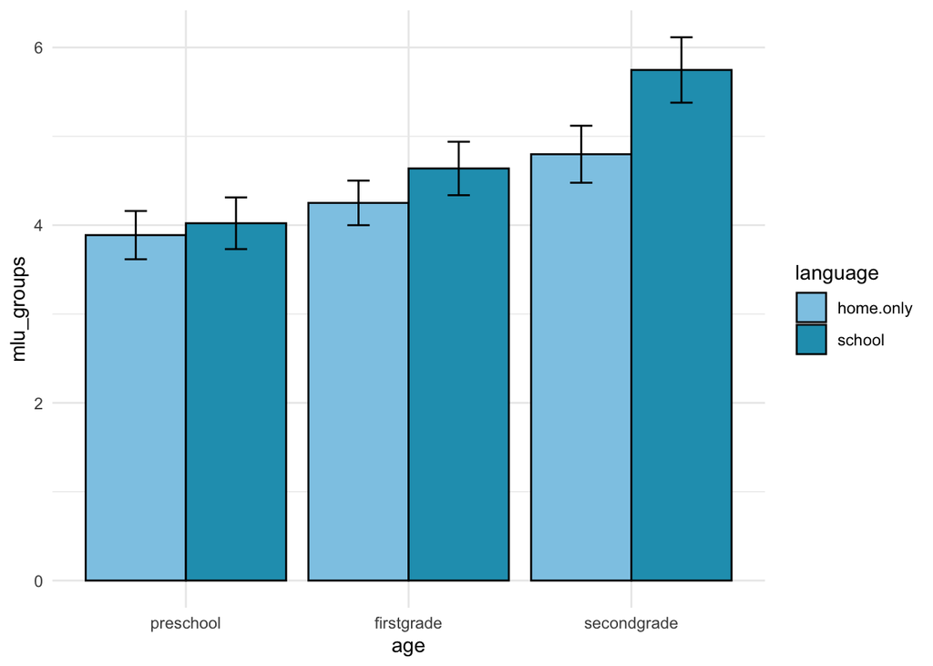

```r
bilingual_stat %>%
  ggplot(aes(x = age, y = mlu_groups, fill = language)) +
  geom_bar(stat="identity", color="black",
           position=position_dodge()) +
  geom_errorbar(aes(ymin = mlu_groups - mlu_se,
                    ymax = mlu_groups + mlu_se), width=.2, position=position_dodge(.9)) +
  theme_minimal() +
  scale_fill_manual(values=c('#8ECAE6','#219EBC'))
```

Код для слайдов: one-way anova

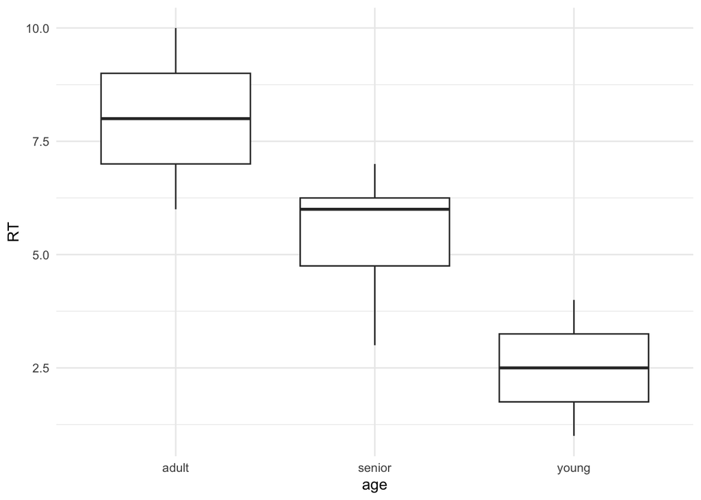

```r
anovadata_wide <- tibble(young = c(3,2,1,1,4,2,4,3),
                    adult = c(10,9,9,8,7,8,6,7),
                    senior = c(7,6,7,6,5,4,3,6))

anovadata <- anovadata_wide %>%
  pivot_longer(cols = young:senior, names_to = "age", values_to = "RT")

ggplot(anovadata, aes(x=age, y=RT)) +
         geom_boxplot() +
         theme_minimal()
```

```r
anovadata %>%
  group_by(by=age) %>%
  summarize(meanRT = mean(RT))
```

```
## # A tibble: 3 × 2
##   by     meanRT
##   <chr>   <dbl>
## 1 adult     8
## 2 senior    5.5
## 3 young     2.5
```

```r
car::leveneTest(anovadata$RT ~ anovadata$age)
```

```
## Levene's Test for Homogeneity of Variance (center = median)
##       Df F value Pr(>F)
## group  2       0      1
##       21
```

```r
# p-value of F close to 1 means that data are homogeneous

model1 <- aov(anovadata$RT ~ anovadata$age)
summary(model1)
```

```
##               Df Sum Sq Mean Sq F value   Pr(>F)
## anovadata$age  2  121.3   60.67   35.39 1.88e-07 ***
## Residuals     21   36.0    1.71
## ---
## Signif. codes:  0 '***' 0.001 '**' 0.01 '*' 0.05 '.' 0.1 ' ' 1
```

```r
#Anova(model1, type=3)
# age has a significant effect

# post-hoc analysis: pairwise comparison
TukeyHSD(model1)
```

```
##   Tukey multiple comparisons of means
##     95% family-wise confidence level
##
## Fit: aov(formula = anovadata$RT ~ anovadata$age)
##
## $`anovadata$age`
##              diff       lwr        upr     p adj
## senior-adult -2.5 -4.150101 -0.8498994 0.0027589
## young-adult  -5.5 -7.150101 -3.8498994 0.0000001
## young-senior -3.0 -4.650101 -1.3498994 0.0004556
```

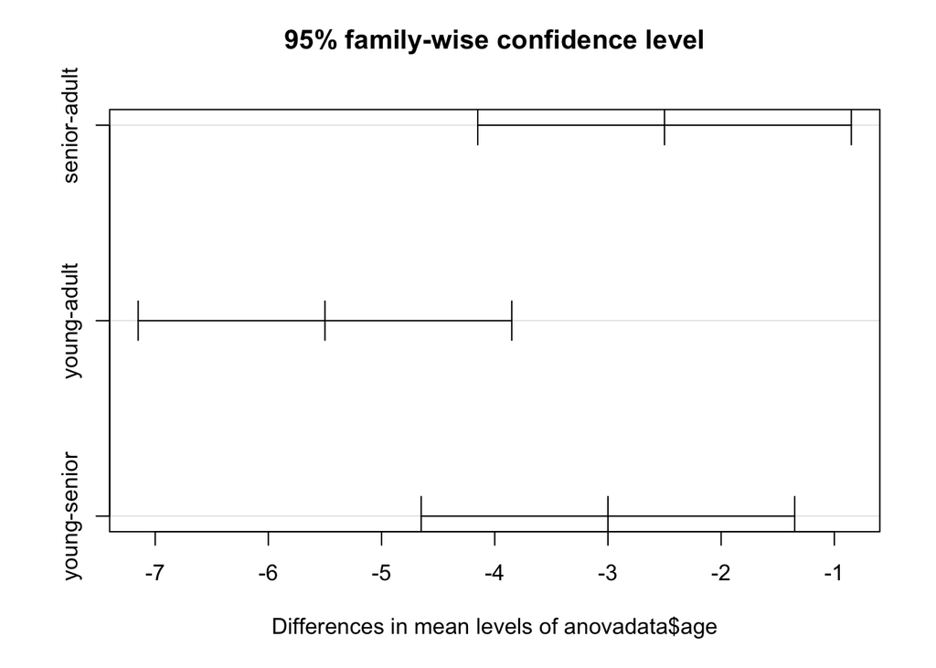

```r
# means in all three group are significantly different from each other
plot(TukeyHSD(model1))
```

```r
pairwise.t.test(anovadata$RT, anovadata$age)
```

```
##
##  Pairwise comparisons using t tests with pooled SD
##
## data:  anovadata$RT and anovadata$age
##
##        adult   senior
## senior 0.00100 -
## young  1.1e-07 0.00032
##
## P value adjustment method: holm
```

```r
pairwise.t.test(anovadata$RT, anovadata$age, p.adjust.method = "bonf")
```

```
##
##  Pairwise comparisons using t tests with pooled SD
##
## data:  anovadata$RT and anovadata$age
##
##        adult   senior
## senior 0.00300 -
## young  1.1e-07 0.00048
##
## P value adjustment method: bonferroni
```

Код для слайдов: RM-anova

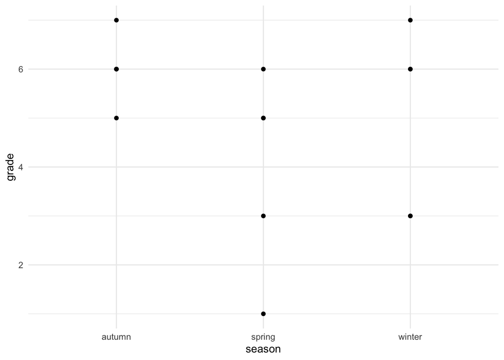

```r
depression <- tibble(id = c(1:5),
                    autumn = c(7,6,6,5,6),
                    winter = c(6,7,3,3,6),
                    spring = c(5,5,6,1,3)) %>%
  pivot_longer(cols = autumn:spring, names_to = "season", values_to = "grade")

ggplot(depression, aes(x=season, y=grade)) +
         geom_point() +
         theme_minimal()
```

```r
depression %>%
  group_by(season) %>%
  get_summary_stats(grade, type = "mean_sd")
```

```
## # A tibble: 3 × 5
##   season variable     n  mean    sd
##   <chr>  <fct>    <dbl> <dbl> <dbl>
## 1 autumn grade        5     6 0.707
## 2 spring grade        5     4 2
## 3 winter grade        5     5 1.87
```

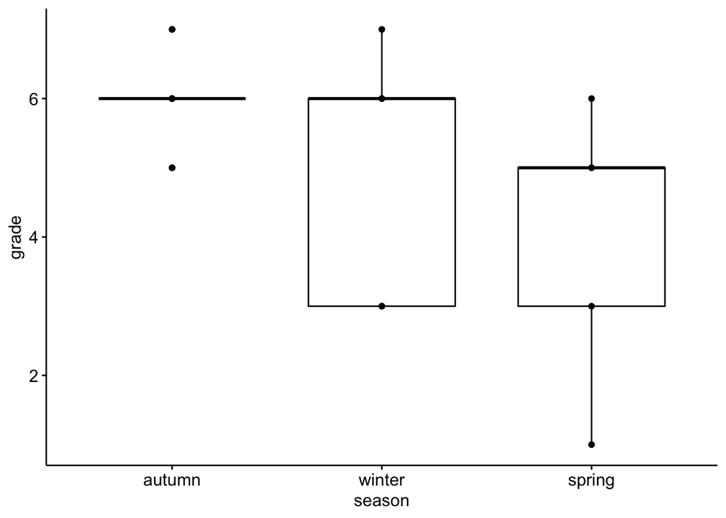

```r
ggboxplot(depression, x = "season", y = "grade", add = "point")
```

```r
# extreme outliers
depression %>%
  group_by(season) %>%
  identify_outliers(grade)
```

```
## # A tibble: 2 × 5
##   season    id grade is.outlier is.extreme
##   <chr>  <int> <dbl> <lgl>      <lgl>
## 1 autumn     1     7 TRUE       TRUE
## 2 autumn     4     5 TRUE       TRUE
```

```r
# 1) remove extreme outliers, 2) compare models with and without outliers, 3) perform robust ANOVA test using the WRS2 package

# normality test
depression %>%
  group_by(season) %>%
  shapiro_test(grade)
```

```
## # A tibble: 3 × 4
##   season variable statistic     p
##   <chr>  <chr>        <dbl> <dbl>
## 1 autumn grade        0.883 0.325
## 2 spring grade        0.905 0.440
## 3 winter grade        0.817 0.111
```

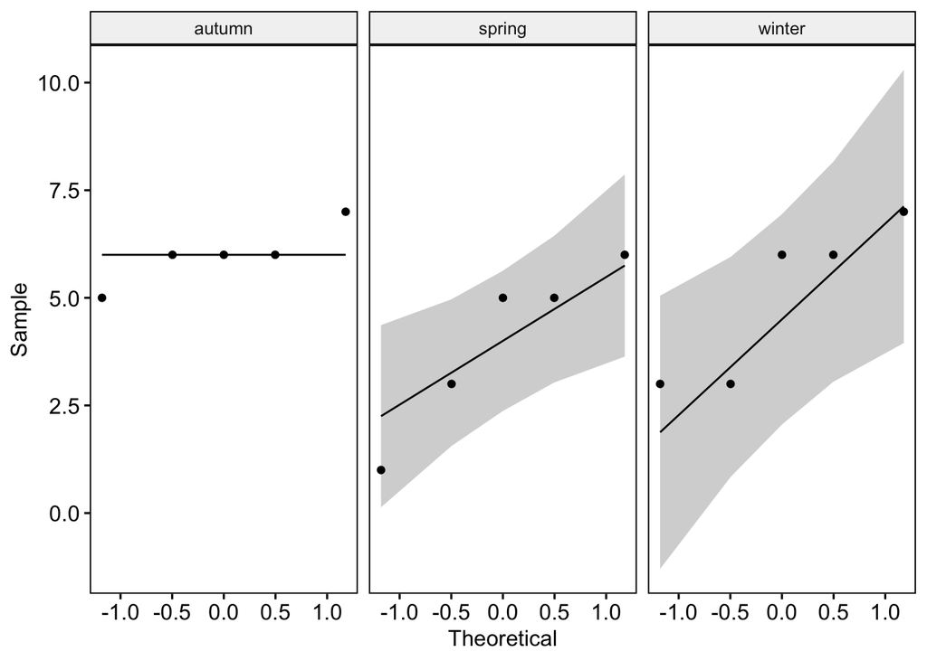

```r
# data normally distributed in each seasons, p>0.5

ggqqplot(depression, "grade", facet.by = "season")
```

```r
res.aov <- anova_test(data = depression, dv = grade, wid = id, within = season)
get_anova_table(res.aov)
```

```
## ANOVA Table (type III tests)
##
##   Effect DFn DFd     F     p p<.05   ges
## 1 season   2   8 2.857 0.116       0.238
```

```r
# p-value > 0.5, so there is no significant difference found across seasons

# post-hoc analysis: pairwise comparison
pwc <- depression %>%
  pairwise_t_test(
    grade ~ season, paired = TRUE,
    p.adjust.method = "bonferroni"
    )
pwc
```

```
## # A tibble: 3 × 10
##   .y.   group1 group2    n1    n2 statistic    df     p p.adj p.adj.signif
## * <chr> <chr>  <chr>  <int> <int>     <dbl> <dbl> <dbl> <dbl> <chr>
## 1 grade autumn spring     5     5     2.83      4 0.047 0.142 ns
## 2 grade autumn winter     5     5     1.41      4 0.23  0.69  ns
## 3 grade spring winter     5     5    -0.953     4 0.394 1     ns
```

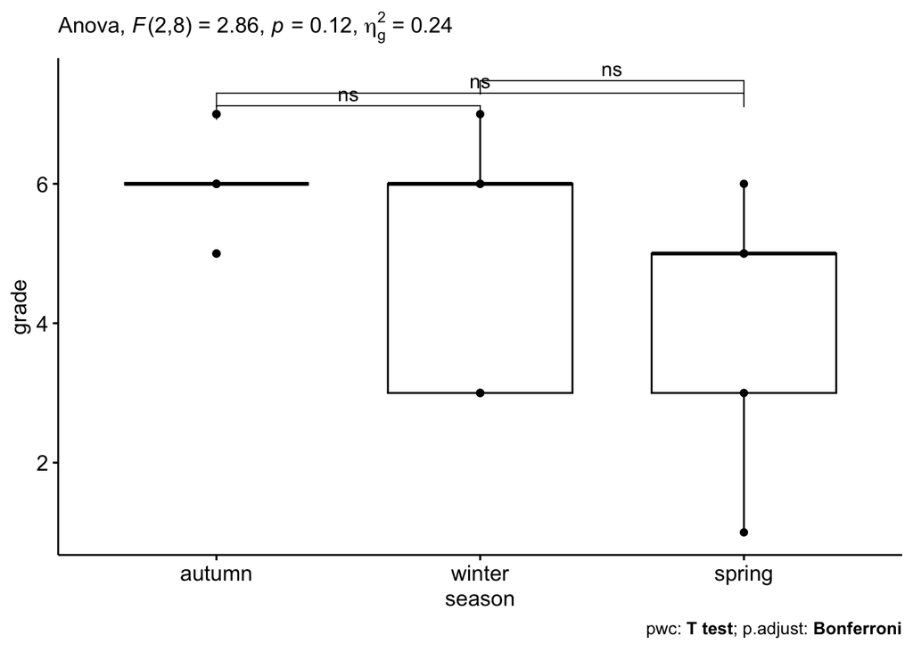

```r
# Visualization: box plots with p-values
pwc <- pwc %>% add_xy_position(x = "season")
ggboxplot(depression, x = "season", y = "grade", add = "point") +
  stat_pvalue_manual(pwc) +
  labs(
    subtitle = get_test_label(res.aov, detailed = TRUE),
    caption = get_pwc_label(pwc)
  )
```

Взаимодействие (interaction) переменных:

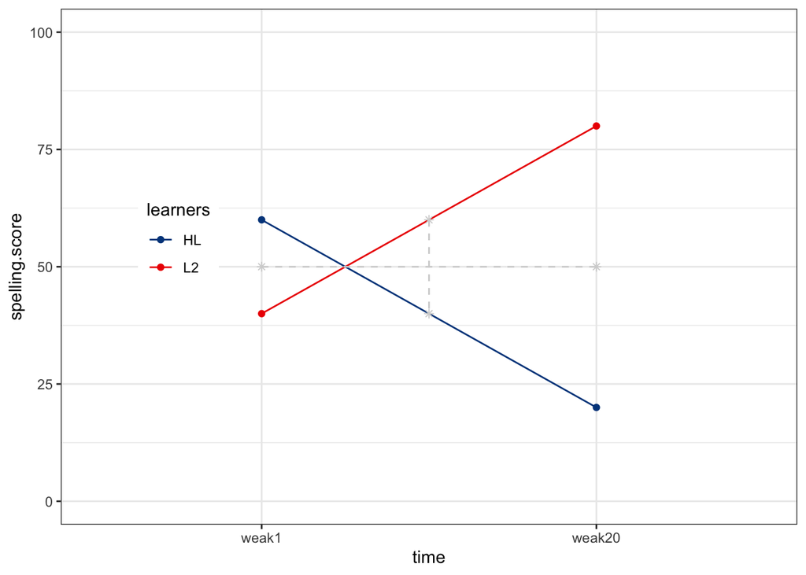

```r
grades <- tibble(learners = c("HL", "HL", "L2", "L2"),
                 time = c("weak1", "weak20", "weak1", "weak20"),
                 spelling.score = c(60,20,40,80))

points <- tribble(
  ~Point, ~Y, ~X,
  "point 1", 50, 1,
  "point 2", 50, 2,
  "point 3", NA, NA,
  "point 4", 60, 1.5,
  "point 5", 40, 1.5
)

grades %>%
  ggplot() +
  aes(x = time, y = spelling.score, color = learners) +
  geom_line(aes(group = learners)) +
  geom_point() +
  ylim(0,100) +
  geom_point(data=points, aes(x = X, y = Y), color="lightgrey", shape=8) +
  geom_path(data=points, aes(x = X, y = Y), color="lightgrey", linetype=2) +
  scale_color_lancet() +
  theme_bw() +
  theme(legend.position=c(0.16,0.55))
```

Шпаргалка по ANOVA: * https://www.krigolsonteaching.com/uploads/4/3/8/4/43848243/r_coding_cheat_sheet.pdf